# Load Data

```python
import pandas as pd

df_CloudServiceData = pd.read_csv('https://storage.googleapis.com/datalynn-datasets/interview-challenge/technology/IBM_Cloud_Services/CloudServiceData.csv')
print(df_CloudServiceData.head())
```

```
    UserID          SessionDate  DataProcessed_GB  ProcessingSpeed_MBps  \
0  USR0001  2022-04-11 10:04:00         59.820442              6.138632
1  USR0002  2022-10-24 00:23:00         41.341754              5.161112
2  USR0003  2022-10-12 02:25:00         36.509420              4.829391
3  USR0004  2022-01-15 02:43:00         55.807495              5.379262
4  USR0005  2022-03-23 23:14:00        103.055253             10.054415

   Downtime_Min ServicePlan  UserFeedbackScore  AdClicked  DatasetSize_GB
0      1.939295       Basic                  8          0       59.932660
1      3.663241       Basic                  9          1       42.188588
2      1.280563       Basic                  9          0       34.957295
3      6.004345       Basic                  8          0       61.823031
4      0.872311         Pro                 10          1       96.648907
```

## Question 1

**Scenario:** It's known that different service plans might have varying levels of user satisfaction due to the differentiated resources allocated to them. By looking into the data, **provide insights** into how the average processing speed and downtime impact the user feedback score across different service plans.

```
Initial Descriptive Statistics:
       DataProcessed_GB  ProcessingSpeed_MBps  Downtime_Min  \
count       1000.000000           1000.000000   1000.000000
mean          77.235180              7.360092      4.885817
std           46.696083              4.712825      4.774588
min           12.583000              0.830562      0.005346
25%           46.550289              4.382954      1.444828
50%           58.760552              5.538976      3.341399
75%           96.294358              9.392146      6.950844
max          274.554171             26.736372     43.577372

       UserFeedbackScore    AdClicked  DatasetSize_GB
count        1000.000000  1000.000000     1000.000000
mean            8.946000     0.400000       77.506335
std             1.117288     0.490143       46.813213
min             4.000000     0.000000       10.207345
25%             8.000000     0.000000       46.226763
50%             9.000000     0.000000       60.594587
75%            10.000000     1.000000       95.446226
max            10.000000     1.000000      271.444056

Average Metrics by Service Plan:
             ProcessingSpeed_MBps  Downtime_Min  UserFeedbackScore
ServicePlan
Basic                    4.541188      4.931502           8.867987
Enterprise              19.227446      4.709810           9.293478
Pro                      9.401348      4.847764           8.996689
```

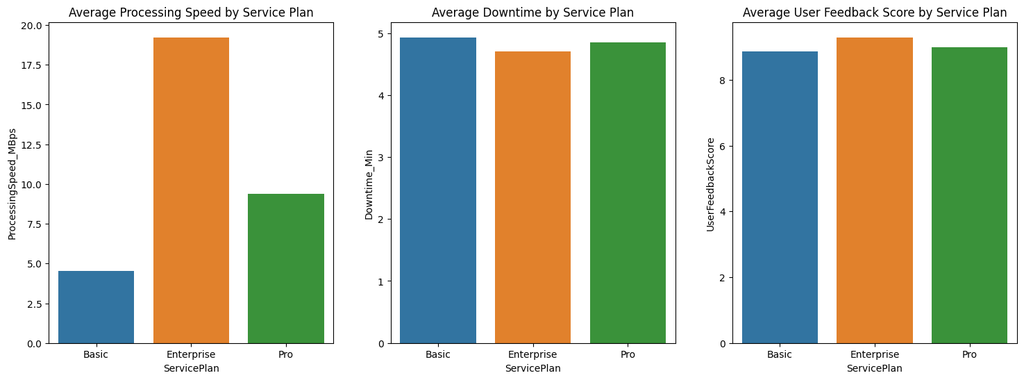

```
Pearson Correlation Matrix:
                      ProcessingSpeed_MBps  Downtime_Min  UserFeedbackScore
ProcessingSpeed_MBps              1.000000     -0.114619           0.191585
Downtime_Min                     -0.114619      1.000000          -0.631883
UserFeedbackScore                 0.191585     -0.631883           1.000000

For Basic Plan:
P-value for correlation between Processing Speed and User Feedback: 7.1330773187345e-20
P-value for correlation between Downtime and User Feedback: 4.208375652947032e-73

For Pro Plan:
P-value for correlation between Processing Speed and User Feedback: 0.00034631798072877246
P-value for correlation between Downtime and User Feedback: 2.0467755298268382e-35

For Enterprise Plan:
P-value for correlation between Processing Speed and User Feedback: 0.16943418851247577
P-value for correlation between Downtime and User Feedback: 6.28886690503238e-08
```

```python
import pandas as pd
import matplotlib.pyplot as plt
import seaborn as sns
from scipy import stats

df = df_CloudServiceData.copy()
# Initial Descriptive Statistics
print("Initial Descriptive Statistics:")
print(df.describe())

# Grouping data by ServicePlan
grouped_by_serviceplan = df.groupby('ServicePlan')

# Calculate mean for different metrics across ServicePlans
average_metrics = grouped_by_serviceplan[['ProcessingSpeed_MBps', 'Downtime_Min', 'UserFeedbackScore']].mean()
print("\nAverage Metrics by Service Plan:")
print(average_metrics)

# Plotting these metrics
fig, axes = plt.subplots(1, 3, figsize=(18, 6))

sns.barplot(x=average_metrics.index, y=average_metrics['ProcessingSpeed_MBps'], ax=axes[0])
axes[0].set_title('Average Processing Speed by Service Plan')

sns.barplot(x=average_metrics.index, y=average_metrics['Downtime_Min'], ax=axes[1])
axes[1].set_title('Average Downtime by Service Plan')

sns.barplot(x=average_metrics.index, y=average_metrics['UserFeedbackScore'], ax=axes[2])
axes[2].set_title('Average User Feedback Score by Service Plan')

plt.show()

# Pearson Correlation between ProcessingSpeed_MBps, Downtime_Min, and UserFeedbackScore
correlation_matrix = df[['ProcessingSpeed_MBps', 'Downtime_Min', 'UserFeedbackScore']].corr()
print("\nPearson Correlation Matrix:")
print(correlation_matrix)

# Hypothesis Testing for different Service Plans
for plan in df['ServicePlan'].unique():
    data_subset = df[df['ServicePlan'] == plan]
    _, p_value_speed = stats.pearsonr(data_subset['ProcessingSpeed_MBps'], data_subset['UserFeedbackScore'])
    _, p_value_downtime = stats.pearsonr(data_subset['Downtime_Min'], data_subset['UserFeedbackScore'])

    print(f"\nFor {plan} Plan:")
    print(f"P-value for correlation between Processing Speed and User Feedback: {p_value_speed}")
    print(f"P-value for correlation between Downtime and User Feedback: {p_value_downtime}")
```

## Question 2

**Scenario:** The marketing team has been trying to push ads to potential high-end clients. While we have information on which users click on advertisements, the team believes that users who process larger datasets might be more inclined to click on them. **Build a model** predicting if a user will click on an advertisement based on their `DatasetSize_GB`, `ServicePlan`, and `ProcessingSpeed_MBps`. Clearly indicate `AdClicked` as the target variable.

```python
import pandas as pd
from sklearn.model_selection import train_test_split
from sklearn.preprocessing import StandardScaler, OneHotEncoder
from sklearn.compose import ColumnTransformer
from sklearn.pipeline import Pipeline
from sklearn.ensemble import RandomForestClassifier
from sklearn.metrics import classification_report, accuracy_score

# Select features and target variable
features = ['DatasetSize_GB', 'ServicePlan', 'ProcessingSpeed_MBps']
X = df[features]
y = df['AdClicked']

# Split data into training and testing sets
X_train, X_test, y_train, y_test = train_test_split(X, y, test_size=0.2, random_state=42)

# Create a column transformer
preprocessor = ColumnTransformer(
    transformers=[
        ('num', StandardScaler(), ['DatasetSize_GB', 'ProcessingSpeed_MBps']),
        ('cat', OneHotEncoder(), ['ServicePlan'])
    ])

# Create pipeline
pipeline = Pipeline(steps=[('preprocessor', preprocessor),
                           ('classifier', RandomForestClassifier(random_state=10))])

# Fit model
pipeline.fit(X_train, y_train)

# Make predictions
y_pred = pipeline.predict(X_test)

# Evaluate the model
print("Model Accuracy: ", accuracy_score(y_test, y_pred))
print("\nClassification Report: \n", classification_report(y_test, y_pred))
```

```
Model Accuracy:  0.655

Classification Report:
               precision    recall  f1-score   support

           0       0.63      0.85      0.73       108
           1       0.71      0.42      0.53        92

    accuracy                           0.66       200
   macro avg       0.67      0.64      0.63       200
weighted avg       0.67      0.66      0.64       200
```

## Question 3

**Scenario:** The technical team noticed that on days with higher downtimes, the processing speeds tend to drop. Using the data, **determine** if there's a statistically significant relationship between the `Downtime_Min` and `ProcessingSpeed_MBps` on a given `SessionDate`.

```python
import pandas as pd
from scipy.stats import pearsonr

# Group the data by 'SessionDate'
grouped_by_date = df.groupby('SessionDate')

significant_dates = []
non_significant_dates = []

# Iterate through each group to calculate the Pearson correlation
for name, group in grouped_by_date:
    if len(group) >= 3:  # Pearson correlation requires at least 3 data points
        correlation, p_value = pearsonr(group['Downtime_Min'], group['ProcessingSpeed_MBps'])

        print(f"On {name}, Pearson correlation: {correlation}, p-value: {p_value}")

        if p_value < 0.05:
            print(f"The relationship is statistically significant on {name}.")
            significant_dates.append(name)
        else:
            print(f"The relationship is not statistically significant on {name}.")
            non_significant_dates.append(name)

print("\nDates with significant relationship:", significant_dates)
```

```
Dates with significant relationship: []
```

## Question 4

**Scenario:** To improve our cloud service, we want to give additional resources to users who might require higher processing speeds. **Using the data**, find a subset of users who consistently show a higher average of `DataProcessed_GB` but have a lower `ProcessingSpeed_MBps`. This will help in identifying potential candidates for a service plan upgrade.

```python
import pandas as pd

# Step 1: Group Data by UserID
grouped_by_user = df.groupby('UserID').agg({
    'DataProcessed_GB': 'mean',
    'ProcessingSpeed_MBps': 'mean'
})

# Step 2: Rank Users
grouped_by_user['Rank_DataProcessed'] = grouped_by_user['DataProcessed_GB'].rank(ascending=False)  # Higher GB should get a lower rank (i.e., better)
grouped_by_user['Rank_ProcessingSpeed'] = grouped_by_user['ProcessingSpeed_MBps'].rank(ascending=True)  # Lower speed should get a lower rank (i.e., worse)

# Step 3: Identify Candidates for Upgrade
# Users with Rank_DataProcessed <= 20 and Rank_ProcessingSpeed >= 80 could be considered for an upgrade
candidates_for_upgrade = grouped_by_user[
    (grouped_by_user['Rank_DataProcessed'] <= 20) &
    (grouped_by_user['Rank_ProcessingSpeed'] >= 80)
]
# Display the candidates
print("Candidates for Service Plan Upgrade:")
print(candidates_for_upgrade)
```

```
Candidates for Service Plan Upgrade:
         DataProcessed_GB  ProcessingSpeed_MBps  Rank_DataProcessed  \
UserID
USR0134        231.109422             22.796083                19.0
USR0194        242.581989             19.001256                11.0
USR0263        241.117155             11.674911                13.0
USR0356        271.650439             18.367056                 2.0
USR0401        243.477724             20.390014                10.0
USR0471        232.015473             21.425845                17.0
USR0501        274.554171             20.306369                 1.0
USR0505        260.858194             16.463882                 3.0
USR0561        252.010279             19.415739                 6.0
USR0585        251.610138             13.196351                 7.0
USR0594        234.633365             21.906278                14.0
USR0596        245.158816             21.334985                 9.0
USR0647        232.626877             22.632276                16.0
USR0652        241.512035             21.877257                12.0
USR0686        258.518589             22.926956                 4.0
USR0713        231.208726             22.461198                18.0
USR0722        234.114891             16.281011                15.0
USR0734        228.962137             25.299289                20.0
USR0741        251.280106             26.289401                 8.0
USR0773        256.094076             13.886854                 5.0

         Rank_ProcessingSpeed
UserID
USR0134                 989.0
USR0194                 950.0
USR0263                 871.0
USR0356                 944.0
USR0401                 962.0
USR0471                 975.0
USR0501                 961.0
USR0505                 927.0
USR0561                 952.0
USR0585                 905.0
USR0594                 981.0
USR0596                 973.0
USR0647                 987.0
USR0652                 980.0
USR0686                 990.0
USR0713                 985.0
USR0722                 925.0
USR0734                 996.0
USR0741                 998.0
USR0773                 915.0
```